# Using Machine Learning to predict how a weight lifting exercise is performed

M. G. Kirtland Grech

2/28/2021

### Introduction

The original weight lifting expercise that was carried out to acquire the data used in this study is described on the [Human Activity Recognition (HAR)](http://web.archive.org/web/20161224072740/http:/groupware.les.inf.puc-rio.br/har). The data contains accelerometer, gyroscope and magnetometer measurements recorded while 6 participants were performing unilateral dumbbell biceps curl. Each participant repeated the exercise 10 times in 5 different ways (labeled as Class A through Class E). Class A corresponds to the exercise being done correctly, whereas each of the other classes corresponds to a specific mistake in performing the exercise. The objective of this study is to determine whether we can detect *how* an exercise was being done by assigning it to its specific class. This information is stored in the feature *classe*.

### Exploratory Data Analysis

Two datasets were used in this analysis: a training dataset which was used for training and validation, and a testing dataset on which the final prediction was performed and answers submitted to the quiz. The datasets are available at these links and were read straight into R using the **read.csv()** function:

training: https://d396qusza40orc.cloudfront.net/predmachlearn/pml-training.csv

testing: https://d396qusza40orc.cloudfront.net/predmachlearn/pml-testing.cs

The first step is to perform some exploratory data analysis to get a better understanding of the data, apply any data cleaning that might be needed and determine which features should be selected for the modeling exercise. The training data set contains 19622 observations with 160 variables (features), whereas the testing dataset contains 20 observations of 160 variables (features). An example of the first 20 features of the training dataset is shown below.

```
## 'data.frame':    19622 obs. of  160 variables:
##  $ X                       : int  1 2 3 4 5 6 7 8 ...
##  $ user_name               : chr  "carlitos" "carlitos" "carlitos" ...
##  $ raw_timestamp_part_1    : int  1323084231 1323084231 1323084231 1323084232 1323084232 1323084232 1323084232 1323084232 ...
##  $ raw_timestamp_part_2    : int  788290 808298 820366 120339 196328 304277 368296 440390 ...
##  $ cvtd_timestamp          : chr  "05/12/2011 11:23" "05/12/2011 11:23" "05/12/2011 11:23" ...
##  $ new_window              : chr  "no" "no" "no" ...
##  $ num_window              : int  11 11 11 12 12 12 12 12 ...
##  $ roll_belt               : num  1.41 1.41 1.42 1.48 1.48 1.45 1.42 1.42 ...
##  $ pitch_belt              : num  8.07 8.07 8.07 8.05 8.07 8.06 8.09 8.13 ...
##  $ yaw_belt                : num  -94.4 -94.4 -94.4 -94.4 -94.4 -94.4 -94.4 -94.4 ...
##  $ total_accel_belt        : int  3 3 3 3 3 3 3 3 ...
##  $ kurtosis_roll_belt      : chr  "" "" "" ...
##  $ kurtosis_picth_belt     : chr  "" "" "" ...
##  $ kurtosis_yaw_belt       : chr  "" "" "" ...
##  $ skewness_roll_belt      : chr  "" "" "" ...
##  $ skewness_roll_belt.1    : chr  "" "" "" ...
##  $ skewness_yaw_belt       : chr  "" "" "" ...
##  $ max_roll_belt           : num  NA NA NA NA NA NA NA NA ...
##  $ max_picth_belt          : int  NA NA NA NA NA NA NA NA ...
##  $ max_yaw_belt            : chr  "" "" "" ...
##   [list output truncated]
```

As can be seen from the above some of the 160 features of them contained mostly NA, empty character strings (" ") or *#div0/0!*. Since the number of observations with these values was so large, it was deemed safer to eliminate these features rather than try to impute them. In addition, since accelerometer measurements are the focus of this study, gyroscope and magnetometer data were also excluded. Finally, since the features in the first seven columns do not contain useful information for this study, they were also removed.

The following shows the first 20 features of the training dataset after data cleaning was completed. The cleaned up training dataset now consists of 19622 observations of 29 features. The same data preparation steps were also applied to the testing dataset.

```
## 'data.frame':    19622 obs. of  29 variables:
##  $ roll_belt           : num  1.41 1.41 1.42 1.48 1.48 1.45 1.42 1.42 ...
##  $ pitch_belt          : num  8.07 8.07 8.07 8.05 8.07 8.06 8.09 8.13 ...
##  $ yaw_belt            : num  -94.4 -94.4 -94.4 -94.4 -94.4 -94.4 -94.4 -94.4 ...
##  $ total_accel_belt    : int  3 3 3 3 3 3 3 3 ...
##  $ accel_belt_x        : int  -21 -22 -20 -22 -21 -21 -22 -22 ...
##  $ accel_belt_y        : int  4 4 5 3 2 4 3 4 ...
##  $ accel_belt_z        : int  22 22 23 21 24 21 21 21 ...
##  $ roll_arm            : num  -128 -128 -128 -128 -128 -128 -128 -128 ...
##  $ pitch_arm           : num  22.5 22.5 22.5 22.1 22.1 22 21.9 21.8 ...
##  $ yaw_arm             : num  -161 -161 -161 -161 -161 -161 -161 -161 ...
##  $ total_accel_arm     : int  34 34 34 34 34 34 34 34 ...
##  $ accel_arm_x         : int  -288 -290 -289 -289 -289 -289 -289 -289 ...
##  $ accel_arm_y         : int  109 110 110 111 111 111 111 111 ...
##  $ accel_arm_z         : int  -123 -125 -126 -123 -123 -122 -125 -124 ...
##  $ roll_dumbbell       : num  13.1 13.1 12.9 13.4 ...
##  $ pitch_dumbbell      : num  -70.5 -70.6 -70.3 -70.4 ...
##  $ yaw_dumbbell        : num  -84.9 -84.7 -85.1 -84.9 ...
##  $ total_accel_dumbbell: int  37 37 37 37 37 37 37 37 ...
##  $ accel_dumbbell_x    : int  -234 -233 -232 -232 -233 -234 -232 -234 ...
##  $ accel_dumbbell_y    : int  47 47 46 48 48 48 47 46 ...
##   [list output truncated]
```

### Data preparation

After the datasets were cleaned one last step was performed to determine which features were highly correlated with each other. Such features need to be removed as they bring little additional information to the model. 4 features from each data set were identified as having high correlation with the other features and where therefore removed. The resulting final training dataset contained 19622 observations of 25 features and the final testing dataset contained 20 observations of 24 features. Note that is has one less feature compared to the training dataset, namely the feature *classe*, as this is to be predicted.

The next step is to divide the training dataset into a training and validation datasets, with 75% of the data to be used for training and 25% for validation. The validation dataset will be used to test the prediction accuracy of the model prior to using it for prediction on the testing dataset. This is done using the **createDataPartition()** function from the *caret* package in R as shown in the following code:

```r
set.seed(10)
inTrain <- createDataPartition(y=training$classe, p=3/4, list=FALSE)
train_data <- training[inTrain,]
valid_data <- training[-inTrain,]
```

### Model building and evaluation

Two different types of models were fitted, stochastic gradient boosting (**gbm**) and random forest (**rf**). Since the initial results from **gbm** were not as accurate as desired, **expand.grid** was used to tune the model. The metric chosen to evaluate model performance was “Accuracy”. Since the dataset is quite large, parallel processing was also implemented to speed up computation.

Model training and parameter turning was achieved using the **train()** function from the *caret* package. To ensure that the model has a low bias and low variance, k-fold cross validation was used for the resampling scheme, with k set to 10 and specified using **trainControl()**. This was used for both the **gbm** and **rf** models.

```r
# Configure parallel processing
library(parallel)
library(doParallel)
cluster <- makeCluster(detectCores() - 1) # leave 1 core for the operating system
registerDoParallel(cluster)

# Do 6 separate 10 fold cross-validations for the resampling scheme
fit_ctrl <- trainControl(method="repeatedcv",
                         number=10, repeats=6,
                         allowParallel = TRUE)

# Fit a random forest model
set.seed(20)
RF_fit <- train(classe ~ ., method='rf', data=train_data,
                metric="Accuracy",
                trControl = fit_ctrl)

# Fit a gbm model
gbm_grid <- expand.grid(n.trees = (1:30)*5,
                        interaction.depth = c(1,5,9),
                        shrinkage = 0.1,
                        n.minobsinnode =20)

set.seed(20)
GBM_fit <- train(classe ~ ., method='gbm', data=train_data,
                 metric="Accuracy",
                 trControl = fit_ctrl, verbose=FALSE,
                 tuneGrid = gbm_grid)

# Shut down the cluster used for parallel processing
stopCluster(cluster)
registerDoSEQ()
```

The results of the two models can be compared either as a summary (using **resamples()**) or pictorially using box plots as shown in Figure 1. From the summary and box plot comparison we see that the random forest model has a slightly higher accuracy than the stochastic boosting model, hence we will select the random forest model to make predictions on the validation and testing datasets.

[output not shown]

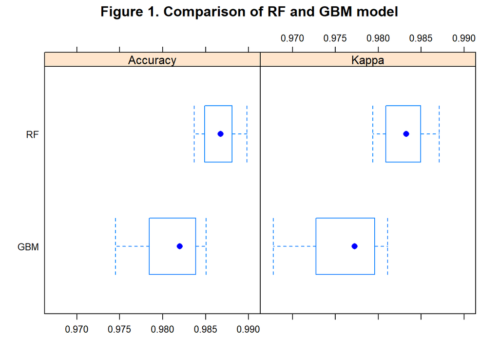

The general effect of predictors on our selected model can be examined using the **varImp()** function and plotted out as show in Figure 2. It shows that the first 4 features had the largest impact on the model, with an importance of 40 or higher.

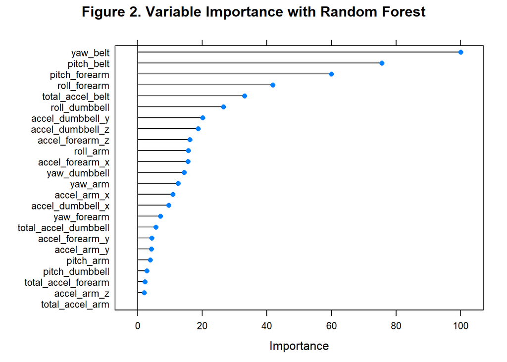

```r
varimp_RF <- varImp(RF_fit)
plot(varimp_RF, main="Figure 2. Variable Importance with Random Forest")
```

### Predict the “classe” on the validation dataset

```r
pred_valid <- predict(RF_fit,valid_data)
table(pred_valid,valid_data$classe)
```

```
##
## pred_valid    A    B    C    D    E
##          A 1387   13    0    0    0
##          B    6  926    7    0    1
##          C    1   10  842   13    2
##          D    0    0    6  791    3
##          E    1    0    0    0  895
```

### Predict the “classe” on the testing dataset

Given the high prediction accuracy obtained on the validation dataset, we can proceed to use it to predict the “classe” on the testing data as shown below. The answers were submitted too the *Course Project Prediction Quiz* as instructed.

```r
pred <- predict(RF_fit,testing)
```